# Logiciel R et données de réseau avec le Package R igraph

Vanesse Labeyrie & Sarah Ouadah

Mardi après-midi 11 Juin 2019

Durée du TP : 1h30

Pré-recquis : possession d’un fichier de données propre dans un format excel suite à la partie 1 de “Gestion de données”

Plan :

1. Présentation du logiciel R
- Généralités
- L’éditeur
- Importation des données
- L’aide de R
- Quelques commandes : Objets et Création de variables, Opérateurs, Sauvegarde
- Packages
2. Créer et manipuler un objet réseau avec le package R igraph
- Liste d’arêtes, matrice d’adjacence et objet igraph
- Attributs de noeuds et d’arêtes
- Opérations sur les graphes

# 1) Présentation du logiciel R

## 1.2) Généralités

R est un logiciel de calcul statistique. Il est constitué d’un noyau de base et de multiples packages développés et mis à disposition de tous par des utilisateurs. Le logiciel RStudio, lui, fournit une interface graphique très conviviale. L’interface de RStudio est divisée en plusieurs fenêtres :

1. l’éditeur, en haut à gauche, qui permet d’écrire du code et de le sauvegarder.
2. la console, en bas à gauche, qui sert à exécuter le code. C’est aussi dans cette fenêtre qu’apparaîtront les résultats des analyses statistiques exécutées.
3. une fenêtre en haut à droite qui contient l’espace de travail et l’historique des commandes.
4. une fenêtre en bas à droite qui regroupe les onglets Files-Plots-Packages-View.

## 1.3) L’éditeur

L’éditeur disponible dans RStudio permet d’écrire le code et de le sauvegarder dans un fichier texte. Cela est particulièrement utile pour y apporter des corrections, pour conserver une trace de vos travaux et relancer des programmes en cas d’interruption de RStudio.

• Si l’éditeur n’apparaît pas à l’ouverture de RStudio , on peut le créer à partir du menu File- New File - R Script .

• Pour sauvegarder le contenu de l’éditeur, on suivra le chemin suivant dans le menu : File -Save as .

Attention : il est vivement conseillé de toujours écrire les instructions dans l’éditeur avant de les exécuter dans la console et d’enregistrer le contenu de l’éditeur régulièrement.

## 1.4) Importation des données

### 1.4.1) Répertoire de travail

Il est pratique de se placer dans un répertoire de travail où se trouvent les données et où seront sauvegardés les résultats et les fichiers de programme. Le choix du répertoire peut se faire à partir du menu Session - Set working directory - choose directory .

– Spécifiez dans R votre répertoire de travail.

### 1.4.2) Importation

Il est nécessaire d’importer les données du fichier dans un tableau de données au format R avant de démarrer toute analyse.

– Chargez vos données file=“mes_donnees.extension” dans une variable nommée par exemple data, à l’aide de la commande

data <- read.table(file, header = FALSE, sep = “”, dec = “.”)

ou encore

data <- read.csv(file, header = TRUE, sep = “,”, quote = “"”, dec = “.”)

Pour cela, placez vous dans l’éditeur et écrivez-y l’instruction. Pour l’exécuter, il faut se placer sur la ligne de la commande puis presser simultanément les touches Ctrl et Entree du clavier, ou encore cliquer sur Run.

Attention : R est sensible à la casse.

Il est à noter que les arguments des fonctions d’importation de données doivent être adaptés à ces données, la description des différents arguments possibles est disponible dans l’aide de R.

## 1.5) L’aide de R

R possède une aide assez complète, accessible via l’onglet Help situé dans la fenêtre en bas à droite de l’interface RStudio. On a accès à un moteur de recherche qui mène à la description des fonctions et à la documentation des packages. La description des fonctions aide à comprendre leur utilisation et leur fonctionnement via des exemples souvent proposés à la fin.

## 1.6) Quelques commandes

### 1.6.1) Objets et Création de variables

R travaille avec des objets. Les données, les graphiques, les fonctions, les résultats d’analyse sont des objets. Des objets courants sont : vector pour un vecteur composé d’une seule variable, data.frame pour un tableau de données et list pour une liste d’objets, généralement le résultat d’une analyse. Pour les réseaux, il existe l’objet igraph. En ce qui concerne les listes, chacun de leurs éléments sont accessibles en tapant le nom de la liste suivi du symbole $ et du nom de l’élément.

Au départ, dans R, le symbole $\leftarrow$ était utilisé pour l’affectation d’un objet; les versions récentes admettent également le symbole = pour l’affectation.

```r
# un vecteur d'attributs quantitatifs
x1 <- c(1,7,8,3,1,8,1,1,2)
x1 = c(1,7,8,3,1,8,1,1,2)

# un vecteur d'attributs qualitatifs
x2 = c("F","M","F", "F","F", "M", "M","M")

# une matrice
x3=matrix(1:6, nrow=3, ncol=3)
```

Pour visualiser les objets crées, il suffit de taper leurs noms, ou d’utiliser la fonction print

```r
x1
```

```
## [1] 1 7 8 3 1 8 1 1 2
```

```r
print(x1)
```

```
## [1] 1 7 8 3 1 8 1 1 2
```

```r
x2
```

```
## [1] "F" "M" "F" "F" "F" "M" "M" "M"
```

```r
x3
```

```
##      [,1] [,2] [,3]
## [1,]    1    4    1
## [2,]    2    5    2
## [3,]    3    6    3
```

La plupart des objets ont un attribut de classe. Les plus courants sont numeric, logical, integer, factor, character, data.frame, etc.

```r
class(x1)
```

```
## [1] "numeric"
```

```r
class(x2)
```

```
## [1] "character"
```

```r
class(x3)
```

```
## [1] "matrix"
```

### 1.6.2) Opérateurs

#### Opérateurs mathématiques

+, ∗, /, −, ^

```r
x1/(10*100)^2
```

```
## [1] 1e-06 7e-06 8e-06 3e-06 1e-06 8e-06 1e-06 1e-06 2e-06
```

#### Opérateurs logiques

& (et), | (ou), ! (négation), == (identité).

```r
x1
```

```
## [1] 1 7 8 3 1 8 1 1 2
```

```r
(x1 < 5) & (x1 ==1)
```

```
## [1]  TRUE FALSE FALSE FALSE  TRUE FALSE  TRUE  TRUE FALSE
```

```r
x2
```

```
## [1] "F" "M" "F" "F" "F" "M" "M" "M"
```

```r
x2=="F"
```

```
## [1]  TRUE FALSE  TRUE  TRUE  TRUE FALSE FALSE FALSE
```

#### Fonctions mathématiques

sqrt(), log(), exp(), …

```r
sqrt(x1)
```

```
## [1] 1.000000 2.645751 2.828427 1.732051 1.000000 2.828427 1.000000 1.000000
## [9] 1.414214
```

#### Fonctions statistiques

min(), max(), sum(), mean(), var(), median(), range(), order(), …

```r
mean(x1)
```

```
## [1] 3.555556
```

```r
var(x1)
```

```
## [1] 10.02778
```

```r
min(x1)
```

```
## [1] 1
```

```r
range(x1)
```

```
## [1] 1 8
```

```r
summary(x1)
```

```
##    Min. 1st Qu.  Median    Mean 3rd Qu.    Max.
##   1.000   1.000   2.000   3.556   7.000   8.000
```

```r
sort(x1)
```

```
## [1] 1 1 1 1 2 3 7 8 8
```

#### Opérations vectorielles

extraction vec[i], mat[i,j], mat[,j] où (i : ligne, j : colonne)

```r
x1[9]
```

```
## [1] 2
```

```r
x3[1,2]
```

```
## [1] 4
```

```r
x3[,2]
```

```
## [1] 4 5 6
```

```r
# suppression vec[-i]
x1[-5]
```

```
## [1] 1 7 8 3 8 1 1 2
```

### 1.6.3) Sauvegarde

R propose à la fin de chaque session de sauvegarder tout l’espace de travail. Celui-ci est en général énorme et contient beaucoup d’objets intermédiaires inutiles. Pour sauvegarder uniquement quelques objets, utiliser la fonction save(). Pour charger les données sauvegardées utiliser la fonction load().

```r
x = runif(20)
y = list(a = 1, b = TRUE, c = "oops")
save(x, y, file = "xy.RData")
rm(x)
rm(y)
load("xy.RData")
x
```

```
##  [1] 0.367581934 0.424395928 0.667798637 0.186101568 0.503518046
##  [6] 0.410964576 0.891906659 0.791192224 0.118662414 0.350409010
## [11] 0.513457604 0.127641500 0.770687776 0.490395264 0.006786022
## [16] 0.440665672 0.724110509 0.914043279 0.307549072 0.085484232
```

```r
y
```

```
## $a
## [1] 1
##
## $b
## [1] TRUE
##
## $c
## [1] "oops"
```

Pour exporter un tableau :

```r
x3
```

```
##      [,1] [,2] [,3]
## [1,]    1    4    1
## [2,]    2    5    2
## [3,]    3    6    3
```

```r
write.table(x3,file="matrix.txt",quote=FALSE,row.names=FALSE,col.names=c("A1","A2", "A3"))
```

Pour sauvegarder un graphique : on peut utiliser Export de l’onglet Plots situé dans la fenêtre en bas à droite de l’interface RStudio.

## 1.7) Packages

### 1.7.1) Installation d’un package R

- Avec une connexion internet :

install.packages(“nom_package”)

ou

aller dans l’onglet Tools - Install Packages - puis choisir Repositery (Cran) pour la case “Install from” et inscrire le nom du package pour la case “Packages”.

- A partir d’un fichier stocké sur votre ordinateur :

install.packages(“~/chemin/nom_package”, repos = NULL, type = “source”)

où chemin indique où est le dossier où se trouve le package, par exemple “/home/R/packages/”

ou

aller dans l’onglet Tools - Install Packages - , puis choisir Package Archive File (.tar.gz) pour la case “Install from”, puis cliquer sur Browse pour sélectionner le fichier package.

Avant d’utiliser un package on va le chercher dans notre library avec la commande :

library(nom_package)

### 1.7.2) Les packages utiles pour la formation

```r
library(igraph)
library(igraphdata)
library(sand)
library(blockmodels)
library(ggplot2)
```

# 2) Créer et manipuler un objet réseau avec le package R igraph

## 2.1) Liste d’arêtes, matrice d’adjacence et objet igraph

### 2.1.1) Exemple : graphe des relations de travail entre avocats au sein d’un cabinet.

E. Lazega, The Collegial Phenomenon: The Social Mechanisms of Cooperation Among Peers in a Corporate Law Partnership. Oxford University Press, Oxford (2001).

On considère les données de réseau “lazega” qui viennent d’une étude des partenariats au sein d’un cabinet américain d’avocats du nom de SG&R, collectées entre 1988 et 1991. Elles comportent (entre autres) les réseaux d’interactions entren 71 avocats (partenaires et associés) du cabinet, i.e. les réseaux de collaboration, de conseil et d’amitié. On a également accès à divers attributs des membres tel que l’ancienneté (de 1 pour le plus ancien à 36), le statut, le bureau (ci-après rouge, bleu, jaune), le genre, le lieu d’études, le type de pratique (ci-après rond pour litiges et carré pour affaires), nombre d’années dans le cabinet (ci-après tailles des noeuds proportionnelles), etc. Il est à noter que nous travaillerons sur un sous-ensemble des données incluant 36 partenaires du cabinet.

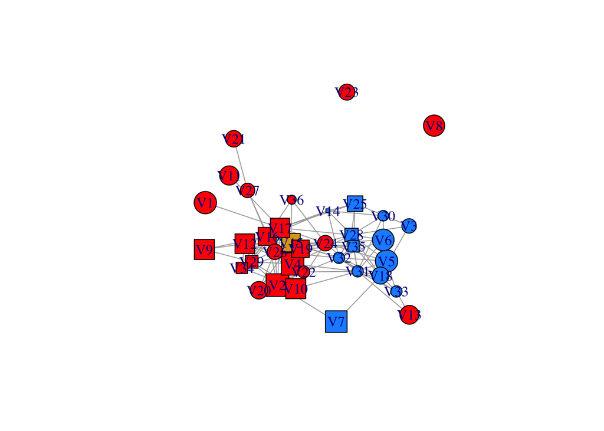

L’information principale d’un graphe prend ces trois formes : liste d’arêtes, matrice d’adjacence et liste d’adjacence qui est déjà un objet igraph.

- Utiliser vos propres données qui sont déjà sous l’une des deux premières formes.

### 2.1.2) Liste d’arêtes

```
##       [,1] [,2]
##  [1,] "V1" "V17"
##  [2,] "V2" "V7"
##  [3,] "V2" "V16"
##  [4,] "V2" "V17"
##  [5,] "V2" "V22"
##  [6,] "V2" "V26"
##  [7,] "V2" "V29"
##  [8,] "V3" "V18"
##  [9,] "V3" "V25"
## [10,] "V3" "V28"
```

Si vous avez une liste d’arêtes, pour créer un objet igraph :

```r
g.lazega=graph_from_edgelist(aretes)
g.lazega
```

```
## IGRAPH 11cc1ce DN-- 34 115 --
## + attr: name (v/c)
## + edges from 11cc1ce (vertex names):
##  [1] V1 ->V17 V2 ->V7  V2 ->V16 V2 ->V17 V2 ->V22 V2 ->V26 V2 ->V29
##  [8] V3 ->V18 V3 ->V25 V3 ->V28 V4 ->V12 V4 ->V17 V4 ->V19 V4 ->V20
## [15] V4 ->V22 V4 ->V26 V4 ->V28 V4 ->V29 V4 ->V31 V5 ->V18 V5 ->V24
## [22] V5 ->V28 V5 ->V31 V5 ->V32 V5 ->V33 V6 ->V24 V6 ->V28 V6 ->V30
## [29] V6 ->V31 V6 ->V32 V7 ->V18 V9 ->V12 V9 ->V16 V9 ->V29 V10->V24
## [36] V10->V26 V10->V29 V10->V31 V10->V34 V11->V17 V12->V15 V12->V16
## [43] V12->V17 V12->V19 V12->V26 V12->V29 V12->V34 V13->V31 V13->V33
## [50] V14->V16 V14->V17 V14->V25 V14->V28 V14->V30 V14->V32 V15->V16
## + ... omitted several edges
```

### 2.1.3) Matrice d’adjacence

Une matrice d’adjacence peut être binaire ou valuée pour un graphe dirigé ou non (symétrique dans ce cas).

```
## 20 x 20 sparse Matrix of class "dgCMatrix"
```

```
##    [[ suppressing 20 column names 'V1', 'V17', 'V2' ... ]]
```

```
##
## V1  . 1 . . . . . . . . . . . . . . . . . .
## V17 . . . . . 1 1 1 . . 1 1 . . 1 . . . 1 .
## V2  . 1 . 1 1 1 1 1 . . . . . . . . . . . .
## V7  . . . . . . . . . 1 . . . . . . . . . .
## V16 . 1 . . . 1 1 1 . . . . . . . . . . . 1
## V22 . . . . . . . . . . . . . . . . 1 . . 1
## V26 . . . . . . . . . . . . . . . . . . . 1
## V29 . . . . . . . . . . . . . . . . . . . .
## V3  . . . . . . . . . 1 1 1 . . . . . . . .
## V18 . . . . . . . . . . . 1 . . . . 1 . . 1
## V25 . . . . . . . . . . . 1 . . . . . . . .
## V28 . . . . . . . . . . . . . . . . 1 . . 1
## V4  . 1 . . . 1 1 1 . . . 1 . 1 1 1 1 . . .
## V12 . 1 . . 1 . 1 1 . . . . . . 1 . . . . .
## V19 . . . . . 1 1 . . . . 1 . . . . . . 1 .
## V20 . . . . . 1 1 . . . . . . . . . . . . .
## V31 . . . . . . . . . . . . . . . . . . . 1
## V5  . . . . . . . . . 1 . 1 . . . . 1 . 1 1
## V24 . . . . . . 1 . . . . . . . . . 1 . . .
## V32 . . . . . . . . . . . . . . . . . . . .
```

Si vous avez une matrice d’adjacence, pour créer un objet igraph :

```r
g.lazega=graph_from_adjacency_matrix(adjacence)
```

#### Formalisme statistique

Un graphe aléatoire $\mathcal{G} =(\mathcal{V}=\{1, \dots n\}, \mathcal{E})$ est la représentation mathématique d’un réseau d’interaction.

Variable d’intérêt - Données : $\mathbf{Y}$ la matrice d’adjacence de $\mathcal{G}$
$$Y_{ij}=\left\{\begin{array}{lcl}
1\mbox{ ou autre valeur}& &\mbox{si $(i, j) \in \mathcal{E}$ (arête)}\\
0& &\mbox{sinon}\end{array}\right.$$

et $Y_{ii} = 0,\forall i$. Lorsque le graphe est non dirigé $Y_{ij} = Y_{ji},\forall i\neq j$.

Remarque : Les $Y_{ij}$ sont des variables aléatoires. Leur réalisations, i.e. les valeurs que l’on observe, se réalisent donc avec une certaine probabilité et proviennent d’un échantillon de la population.

Il existe une classe de graphes dits bipartites $\mathcal{G}_b =(\mathcal{V}_R=\{1, \dots n_V\},\mathcal{V}_C=\{1, \dots n_C\}, \mathcal{E})$. Les arêtes relient des paires de noeuds de différentes natures. $\mathbf{Y}$ est alors appelé la matrice d’incidence avec $i\in\mathcal{V}_R$ en ligne et $i\in\mathcal{V}_C$ en colonne.

### 2.1.4) Liste d’adjacence

```r
g.lazega
```

```
## IGRAPH 93c6cae DN-- 34 115 --
## + attr: name (v/c)
## + edges from 93c6cae (vertex names):
##  [1] V1 ->V17 V2 ->V17 V16->V17 V4 ->V17 V12->V17 V11->V17 V14->V17
##  [8] V2 ->V7  V2 ->V16 V12->V16 V9 ->V16 V15->V16 V14->V16 V17->V22
## [15] V2 ->V22 V16->V22 V4 ->V22 V19->V22 V20->V22 V15->V22 V17->V26
## [22] V2 ->V26 V16->V26 V4 ->V26 V12->V26 V19->V26 V20->V26 V24->V26
## [29] V10->V26 V15->V26 V17->V29 V2 ->V29 V16->V29 V4 ->V29 V12->V29
## [36] V9 ->V29 V10->V29 V15->V29 V7 ->V18 V3 ->V18 V5 ->V18 V17->V25
## [43] V3 ->V25 V14->V25 V17->V28 V3 ->V28 V18->V28 V25->V28 V4 ->V28
## [50] V19->V28 V5 ->V28 V6 ->V28 V14->V28 V4 ->V12 V9 ->V12 V17->V19
## + ... omitted several edges
```

```r
# les noeuds
V(g.lazega)
```

```
## + 34/34 vertices, named, from 93c6cae:
##  [1] V1  V17 V2  V7  V16 V22 V26 V29 V3  V18 V25 V28 V4  V12 V19 V20 V31
## [18] V5  V24 V32 V33 V6  V30 V9  V10 V34 V11 V15 V13 V14 V35 V36 V27 V21
```

```r
# les arêtes
E(g.lazega)
```

```
## + 115/115 edges from 93c6cae (vertex names):
##  [1] V1 ->V17 V2 ->V17 V16->V17 V4 ->V17 V12->V17 V11->V17 V14->V17
##  [8] V2 ->V7  V2 ->V16 V12->V16 V9 ->V16 V15->V16 V14->V16 V17->V22
## [15] V2 ->V22 V16->V22 V4 ->V22 V19->V22 V20->V22 V15->V22 V17->V26
## [22] V2 ->V26 V16->V26 V4 ->V26 V12->V26 V19->V26 V20->V26 V24->V26
## [29] V10->V26 V15->V26 V17->V29 V2 ->V29 V16->V29 V4 ->V29 V12->V29
## [36] V9 ->V29 V10->V29 V15->V29 V7 ->V18 V3 ->V18 V5 ->V18 V17->V25
## [43] V3 ->V25 V14->V25 V17->V28 V3 ->V28 V18->V28 V25->V28 V4 ->V28
## [50] V19->V28 V5 ->V28 V6 ->V28 V14->V28 V4 ->V12 V9 ->V12 V17->V19
## [57] V4 ->V19 V12->V19 V15->V19 V4 ->V20 V15->V20 V22->V31 V18->V31
## [64] V28->V31 V4 ->V31 V5 ->V31 V24->V31 V6 ->V31 V30->V31 V10->V31
## + ... omitted several edges
```

## 2.2) Attributs de noeuds et d’arêtes

Les attributs de noeuds et d’arêtes peuvent être discrets, qualitatifs ou continus. Par exemple, pour les noeuds : genre des acteurs, un statut, une mesure telle que la centralité. Par exemple, pour les arêtes : type ou force de relation.

Pour le réseau lazega

- Nombre de noeuds et attributs :

```r
vcount(g.lazega)
```

```
## [1] 36
```

```r
list.vertex.attributes(g.lazega)
```

```
## [1] "name"      "Seniority" "Status"    "Gender"    "Office"    "Years"
## [7] "Age"       "Practice"  "School"
```

```r
# exemples
V(g.lazega)$Age
```

```
##  [1] 64 62 67 59 59 55 63 53 53 53 50 52 57 56 48 46 50 45 46 49 43 49 45
## [24] 44 43 41 47 38 38 39 34 33 37 36 33 43
```

```r
V(g.lazega)$Gender
```

```
##  [1] 1 1 1 1 1 1 1 1 1 1 1 1 1 1 1 1 1 1 1 1 1 1 1 1 1 1 2 1 2 1 1 1 1 2 1
## [36] 1
```

- Nombre d’arêtes:

```r
ecount(g.lazega)
```

```
## [1] 115
```

Pour ce graphe dirigé

```
## IGRAPH ed5c754 DN-- 3 4 --
## + attr: name (v/c)
## + edges from ed5c754 (vertex names):
## [1] 1->2 1->3 2->3 3->2
```

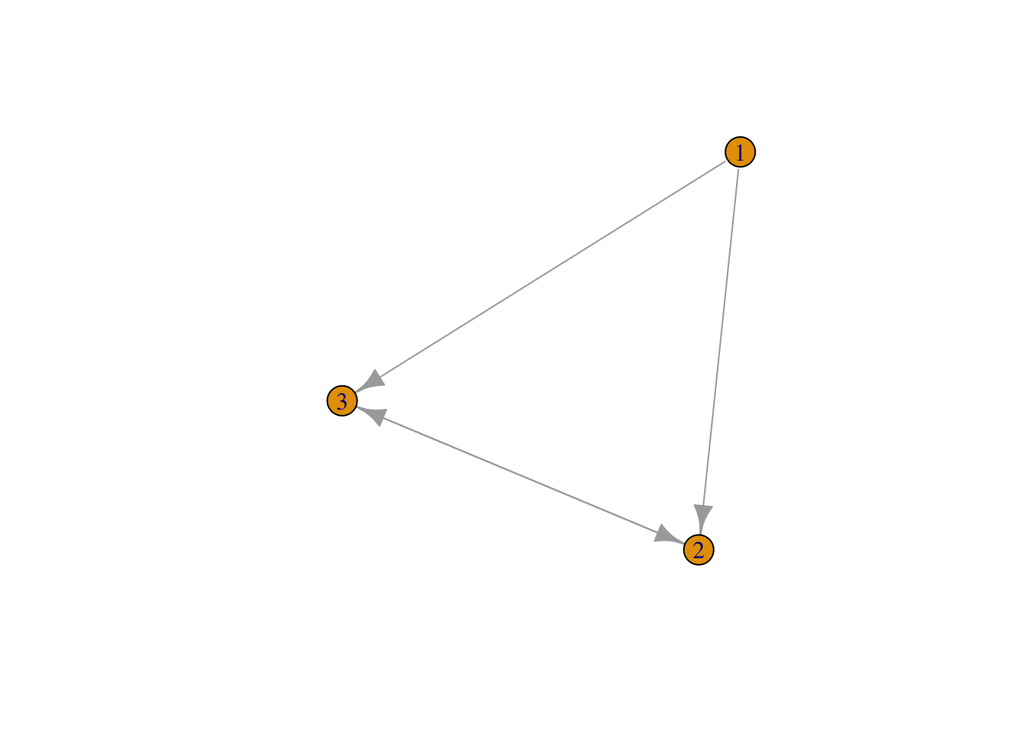

```r
dg <- graph.formula(1-+2, 1-+3, 2++3)
dg
```

- Nommer les noeuds, les colorer, leur donner un poids a posteriori :

```r
V(dg)
```

```
## + 3/3 vertices, named, from ed5c754:
## [1] 1 2 3
```

```r
V(dg)$name <- c("Adrien", "Claire", "Alex")
V(dg)$name
```

```
## [1] "Adrien" "Claire" "Alex"
```

```r
E(dg)
```

```
## + 4/4 edges from ed5c754 (vertex names):
## [1] Adrien->Claire Adrien->Alex   Claire->Alex   Alex  ->Claire
```

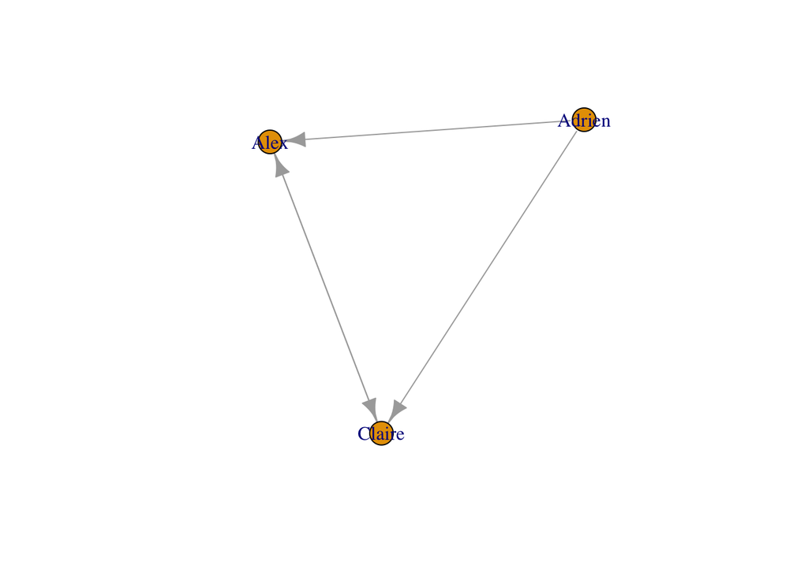

```r
V(dg)$gender <- c("M","F","M")
V(dg)$gender
```

```
## [1] "M" "F" "M"
```

```r
V(dg)$color <- "red"
V(dg)$color
```

```
## [1] "red" "red" "red"
```

```r
is.weighted(dg)
```

```
## [1] FALSE
```

```r
wg <- dg
E(wg)$weight <- runif(ecount(wg))
E(wg)$weight
```

```
## [1] 0.14427955 0.44572420 0.24033372 0.05419922
```

```r
is.weighted(wg)
```

```
## [1] TRUE
```

## 2.3) Opérations sur les graphes

Inclure ou extraire une partie d’un graphe, supprimer des noeuds, ajouter des arêtes, combiner plusieurs graphes, etc :

```
## IGRAPH a270777 UN-- 7 10 --
## + attr: name (v/c)
## + edges from a270777 (vertex names):
##  [1] 1--2 1--3 2--3 2--4 3--5 4--5 4--6 4--7 5--6 6--7
```

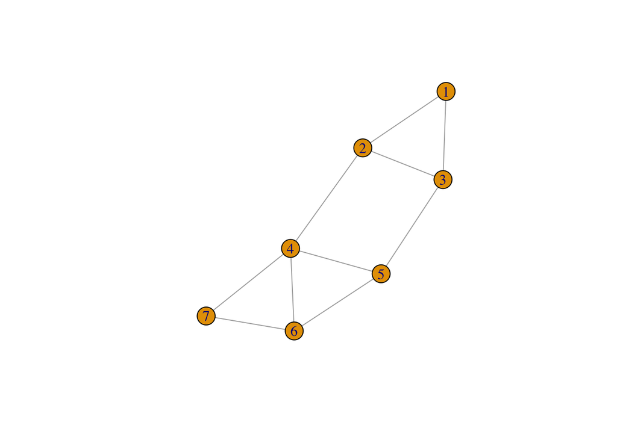

```r
g <- graph.formula(1-2, 1-3, 2-3, 2-4, 3-5, 4-5, 4-6, 4-7, 5-6, 6-7)
g
```

- Graphe induit

via les noms de noeuds :

```r
h <- induced.subgraph(g, 1:5)
h
```

```
## IGRAPH 5b2542e UN-- 5 6 --
## + attr: name (v/c)
## + edges from 5b2542e (vertex names):
## [1] 1--2 1--3 2--3 2--4 3--5 4--5
```

```r
h.lazega <- induced.subgraph(g.lazega, c("V1","V2","V3","V29","V30","V31"))
h.lazega
```

```
## IGRAPH eca9d90 UN-- 6 2 --
## + attr: name (v/c), Seniority (v/n), Status (v/n), Gender (v/n),
## | Office (v/n), Years (v/n), Age (v/n), Practice (v/n), School
## | (v/n)
## + edges from eca9d90 (vertex names):
## [1] V2 --V29 V30--V31
```

via des attributs de noeuds :

```r
h.lazega <- induced.subgraph(g.lazega, V(g.lazega)$Office==1)
h.lazega
```

```
## IGRAPH 264dfa8 UN-- 22 51 --
## + attr: name (v/c), Seniority (v/n), Status (v/n), Gender (v/n),
## | Office (v/n), Years (v/n), Age (v/n), Practice (v/n), School
## | (v/n)
## + edges from 264dfa8 (vertex names):
##  [1] V1 --V17 V2 --V16 V2 --V17 V2 --V22 V2 --V26 V2 --V29 V4 --V12
##  [8] V4 --V17 V4 --V19 V4 --V20 V4 --V22 V4 --V26 V4 --V29 V9 --V12
## [15] V9 --V16 V9 --V29 V10--V24 V10--V26 V10--V29 V10--V34 V11--V17
## [22] V12--V16 V12--V17 V12--V19 V12--V26 V12--V29 V12--V34 V16--V17
## [29] V16--V22 V16--V26 V16--V27 V16--V29 V16--V34 V16--V36 V17--V19
## [36] V17--V22 V17--V24 V17--V26 V17--V29 V17--V34 V19--V22 V19--V24
## + ... omitted several edges
```

```r
V(h.lazega)$Office
```

```
##  [1] 1 1 1 1 1 1 1 1 1 1 1 1 1 1 1 1 1 1 1 1 1 1
```

- Suppression de noeuds

```r
h <- g - vertices(c(6,7))
h
```

```
## IGRAPH 9b19382 UN-- 5 6 --
## + attr: name (v/c)
## + edges from 9b19382 (vertex names):
## [1] 1--2 1--3 2--3 2--4 3--5 4--5
```

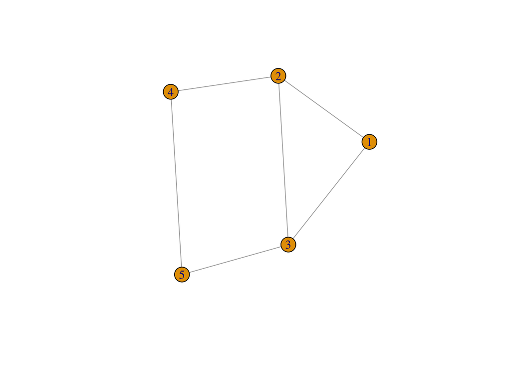

```r
h.lazega <- g.lazega - V(g.lazega)[V(g.lazega)$School==3]
h.lazega
```

```
## IGRAPH 0ad8772 UN-- 23 42 --
## + attr: name (v/c), Seniority (v/n), Status (v/n), Gender (v/n),
## | Office (v/n), Years (v/n), Age (v/n), Practice (v/n), School
## | (v/n)
## + edges from 0ad8772 (vertex names):
##  [1] V1 --V17 V2 --V16 V2 --V17 V3 --V18 V3 --V25 V3 --V28 V5 --V18
##  [8] V5 --V24 V5 --V28 V5 --V31 V6 --V24 V6 --V28 V6 --V31 V9 --V12
## [15] V9 --V16 V11--V17 V12--V16 V12--V17 V12--V19 V12--V34 V13--V31
## [22] V14--V16 V14--V17 V14--V25 V14--V28 V16--V17 V16--V27 V16--V34
## [29] V17--V19 V17--V24 V17--V25 V17--V28 V17--V34 V18--V28 V18--V31
## [36] V19--V24 V19--V28 V19--V34 V21--V27 V24--V31 V25--V28 V28--V31
```

```r
V(h.lazega)$School
```

```
##  [1] 1 1 1 2 1 1 1 2 2 1 1 1 2 1 1 2 2 2 2 1 2 2 2
```

- Ajout de noeuds et d’arêtes

```r
h <- h + vertices(c(6,7))
h
```

```
## IGRAPH b4bdc3b UN-- 7 6 --
## + attr: name (v/c)
## + edges from b4bdc3b (vertex names):
## [1] 1--2 1--3 2--3 2--4 3--5 4--5
```

```r
g <- h + edges(c(4,6),c(4,7),c(5,6),c(6,7))
g
```

```
## IGRAPH 389bf95 UN-- 7 10 --
## + attr: name (v/c)
## + edges from 389bf95 (vertex names):
##  [1] 1--2 1--3 2--3 2--4 3--5 4--5 4--6 4--7 5--6 6--7
```

- Union de graphes

```r
h1 <- h
h1
```

```
## IGRAPH b4bdc3b UN-- 7 6 --
## + attr: name (v/c)
## + edges from b4bdc3b (vertex names):
## [1] 1--2 1--3 2--3 2--4 3--5 4--5
```

```r
h2 <- graph.formula(4-6, 4-7, 5-6, 6-7)
h2
```

```
## IGRAPH 72dd46a UN-- 4 4 --
## + attr: name (v/c)
## + edges from 72dd46a (vertex names):
## [1] 4--6 4--7 6--7 6--5
```

```r
g <- graph.union(h1,h2)
g
```

```
## IGRAPH 719a98c UN-- 7 10 --
## + attr: name (v/c)
## + edges from 719a98c (vertex names):
##  [1] 6--7 5--6 4--7 4--6 4--5 3--5 2--4 2--3 1--3 1--2
```